# Untitled

2022-11-03

```r
library(here) #nice file paths
library(readxl) #read in excel data
library(tidyverse) #collection of packages for data science
```

```r
library(patchwork) #"stiches" together ggplots
library(magrittr) #pipes
library(broom) #tidy displays
library(ggrepel) #for labelling points on a ggplot
library(lubridate) #helps with date objects
library(bacondecomp) #Goodman Bacon Decomposition
library(did) #Callaway and Sant'Anna estimator for DID
library(staggered) #Sun and Abraham estimator for DID

source("./helper_func_ed.R")
source("./helper_func_ed_sum.R")
source("./helper_func_ed_sum_hte.R")

colorize <- function(x, color) {
  if (knitr::is_latex_output()) {
    sprintf("\\textcolor{%s}{%s}", color, x)
  } else if (knitr::is_html_output()) {
    sprintf("<b><span style='color: %s;'>%s</span></b>", color,
      x)
  } else x
}

library(r2symbols)
library(emo)
```

# Scenario 7 (4 states, staggered timing, heterogeneous effects)

Scenario 7 is similar to Scenario 5 except now the treatment effect is different for the two treated states, i.e., it is heterogeneous.

```r
# here we also specify the range of the data to be read into R because we don't
# want to include other information included in this sheet
s7 <- read_xlsx(here("data", "scenarios.xlsx"), sheet = "scen7", range = "A1:H81",
                col_types = c("text", "numeric", "text", "numeric", "text", "numeric",
                              "date", "date"))
```

## Visualization of Scenario 7

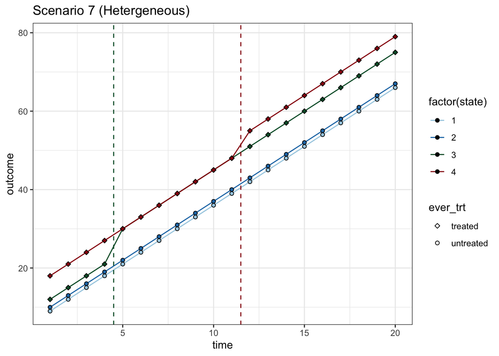

**Visualization of all comparisons made by TWFE regression**

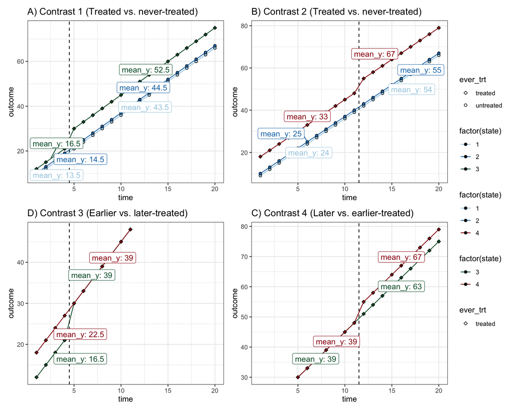

**Contrast 1:**

- Pre-post difference for never-treated state 1 is: 43.5-13.5=30
- Pre-post difference for never-treated state 2 is: 44.5-14.5=30
- Implying the average pre-post difference equals 30 for the never-treated states
- Pre-post difference for treated state 3 is 52.5-16.5 = 36
- $DID_{3 vs 1,2} = 36-30 = 6$

**Contrast 2:**

- Pre-post difference for never-treated state 1 is: 54-24=30
- Pre-post difference for never-treated state 2 is: 55-25=30
- Implying the average pre-post difference equals 30 for the never-treated states
- Pre-post difference for treated state 4 is 67-33= 34
- $DID_{4 vs 1,2} = 34-30 = 4$

**Contrast 3:**

- Pre-post difference for later-treated state 4 is: 39-22.5=16.5
- Pre-post difference for earlier-treated state 3 is: 39-16.5=22.5
- $DID_{3 vs 4} = 22.5-16.5 = 6$

**Contrast 4:**

- Pre-post difference for earlier-treated state 3 is: 63-39=24
- Pre-post difference for later-treated state 4 is: 67-39=28
- $DID_{4 vs 3} = 28-24 = 4$

## Calculation of summary measures of the causal effect

Once the setting includes both heterogeneous effects and staggered timing, there is a question of how to aggregate the causal effect estimates across multiple treated units into one estimate. Here are three causal effects that could be calculated:

📘 **Causal Effect A**

Take an average of the estimated effects across the treated units:

$\frac{\text{Number in adoption cohort 1}}{\text{Number of treated units}} \times ATT_{adoption cohort 1} + \frac{\text{Number in adoption cohort 2}}{\text{Number of treated units}} \times ATT_{adoption cohort 2}$

$\frac{1}{2} \times 6 + \frac{1}{2} \times 4 = 5$

📙 **Causal Effect B**

Take an average of the effects across all post-treatment time points:

$\frac{ATT_{t=1} + ATT_{t=2} + ... + ATT_{t=16}}{\text{Number of posttreatment times}}$

$\frac{[5\times9] +[6\times7]}{16}=5.43$

Take a weighted average of the post-treatment-time-specific effects, where the weights correspond to the number of units treated at each time point:

$\frac{2\times{[ATT_{t=1}} +{ATT_{t=2}} + ... + {ATT_{t=9}] + 1\times[{ATT_{t=10} + ... +ATT_{t=16}}}]}{\text{Total number of state-time points}}$

$\frac{2\times(5+5+...+5) + 1\times{(6+...+6)}}{25} = 5.28$

Each of these causal effects are valid measures to calculate and all come with strengths and weaknesses. The researcher needs to decide which one to calculate. Let’s first see how the estimate from the TWFE model compares.

## TWFE Regression Model

```r
s7_mod <- lm(outcome ~ policy + state + factor(time),
             data = s7)
tidy(s7_mod)
```

```
## # A tibble: 24 × 5
##    term          estimate std.error statistic  p.value
##    <chr>            <dbl>     <dbl>     <dbl>    <dbl>
##  1 (Intercept)       8.83     0.191     46.2  2.75e-46
##  2 policy1           4.75     0.151     31.4  3.16e-37
##  3 state2            1.00     0.109      9.15 1.02e-12
##  4 state3            4.00     0.163     24.5  1.20e-31
##  5 state4            8.66     0.129     67.3  2.87e-55
##  6 factor(time)2     3.00     0.244     12.3  1.59e-17
##  7 factor(time)3     6.00     0.244     24.6  1.14e-31
##  8 factor(time)4     9.00     0.244     36.8  5.94e-41
##  9 factor(time)5    12.3      0.247     49.8  4.53e-48
## 10 factor(time)6    15.3      0.247     62.0  2.79e-53
## # … with 14 more rows
```

The coefficient of the policy term equals 4.75. This is smaller than any of 📘 **Causal Effect A** , 📙 **Causal Effect B** , or 📗 **Causal Effect C**. To see how the TWFE came to be this number, we use the Goodman Bacon decomposition to see how much weight each of the contrasts contributes to the effect estimate.

## Goodman Bacon Decomposition

```r
s7 %<>% mutate(state_n = as.numeric(as.character(state)),
               policy_n = as.numeric(as.character(policy)))

s7_bacon <- bacon(outcome ~ policy_n,
      data = s7,
      id_var = "state_n",
      time_var = "time")
```

```
##                       type  weight avg_est
## 1 Earlier vs Later Treated 0.06715 6.00000
## 2 Later vs Earlier Treated 0.15108 4.00000
## 3     Treated vs Untreated 0.78177 4.78528
```

It is more helpful to view the four contrasts separately:

```r
s7_bacon
```

```
##   treated untreated estimate     weight                     type
## 2       5     99999        6 0.30695444     Treated vs Untreated
## 3      12     99999        4 0.47482014     Treated vs Untreated
## 6      12         5        4 0.15107914 Later vs Earlier Treated
## 8       5        12        6 0.06714628 Earlier vs Later Treated
```

The estimates of the treatment effects for each contrast are as we calculated them above. However, the TWFE’s estimate of 4.75, is pulled towards 4, because the combined weight put on the effect estimate of 4 is higher than the combined weight put on the effect estimate of 6. This leads to an effect estimate from TWFE that is smaller than any of the causal effect estimates.

The TWFE regression estimate is estimating a different causal estimand than any of the three with initially proposed. The new proposed estimators overcome this issue and are considered next.

## Group-Time ATT Estimator

Like in the earlier examples we start by running the `att_gt()` function.

```r
s7_cs <- att_gt(yname = "outcome",
             tname = "time",
             idname = "state_n",
             gname = "time_first_treat",
             data = s7,
             control_group = "notyettreated",
             anticipation = 0)
```

```
## No pre-treatment periods to test
```

Callaway and Sant’Anna provide many options for aggregating the group-time effects. The simplest option is specify `type = simple` in the `attge()` function. This estimate considers only the contrasts with a never-treated state (i.e., Comparisons 1 and 2 in the figure above) and combines them into a weighted average, where the weights correspond to each adoption cohort’s time spent in the post-treatment period. For contrast 1, there are 16 time periods post treatment and for contrast 2, there are 9 periods post-treatment. Thus the weighted average is: $6\times(16/25) + 4\times(9/25)=$ 5.28. This is the same as 📗 **Causal Effect C** calculated above.

```r
#aggregate the group time average treatment effects
#type = "simple": weighted average of all group-time average treatment effects
#with weights proportional to the group size
s7_cs_ag <- aggte(s7_cs, type="simple")
summary(s7_cs_ag)
```

```
##
## Call:
## aggte(MP = s7_cs, type = "simple")
##
## Reference: Callaway, Brantly and Pedro H.C. Sant'Anna.  "Difference-in-Differences with Multiple Time Periods." Journal of Econometrics, Vol. 225, No. 2, pp. 200-230, 2021. <https://doi.org/10.1016/j.jeconom.2020.12.001>, <https://arxiv.org/abs/1803.09015>
##
##
##   ATT    Std. Error     [ 95%  Conf. Int.]
##  5.28        0.6832      3.941       6.619 *
##
##
## ---
## Signif. codes: `*' confidence band does not cover 0
##
## Control Group:  Not Yet Treated,  Anticipation Periods:  0
## Estimation Method:  Doubly Robust
```

Alternatively, we can specify `type = "group"` to get separate effect estimates according to time of implementation. In the output `Group` denotes the time of the policy’s introduction for the treated states.

```r
s7_cs_ag2 <- aggte(s7_cs, type = "group")
summary(s7_cs_ag2)
```

```
##
## Call:
## aggte(MP = s7_cs, type = "group")
##
## Reference: Callaway, Brantly and Pedro H.C. Sant'Anna.  "Difference-in-Differences with Multiple Time Periods." Journal of Econometrics, Vol. 225, No. 2, pp. 200-230, 2021. <https://doi.org/10.1016/j.jeconom.2020.12.001>, <https://arxiv.org/abs/1803.09015>
##
##
## Overall summary of ATT's based on group/cohort aggregation:
##  ATT    Std. Error     [ 95%  Conf. Int.]
##    5            NA         NA          NA
##
##
## Group Effects:
##  Group Estimate Std. Error [95% Pointwise  Conf. Band]
##      5        6         NA              NA          NA
##     12        4         NA              NA          NA
## ---
## Signif. codes: `*' confidence band does not cover 0
##
## Control Group:  Not Yet Treated,  Anticipation Periods:  0
## Estimation Method:  Doubly Robust
```

The output also displays an estimate of the Overall ATT, equal to 5. This estimate is different from the one estimated `where type = "simple"`. Here, the estimate is a weighted average, with weights proportional to the number of units in each adoption cohort (e.g., $(1/2)\times 6 + (1/2) \times 4=$ 5). This is equal to 📘 **Causal Effect A** calculated above.

Alternatively, we can specific `type = "dynamic"` to get separate effect estimates for each time period. We can also see that the Overall ATT from this call is equal to 📙 **Causal Effect B** calculated above.

```r
s7_cs_ag2 <- aggte(s7_cs, type = "dynamic")
summary(s7_cs_ag2)
```

```
##
## Call:
## aggte(MP = s7_cs, type = "dynamic")
##
## Reference: Callaway, Brantly and Pedro H.C. Sant'Anna.  "Difference-in-Differences with Multiple Time Periods." Journal of Econometrics, Vol. 225, No. 2, pp. 200-230, 2021. <https://doi.org/10.1016/j.jeconom.2020.12.001>, <https://arxiv.org/abs/1803.09015>
##
##
## Overall summary of ATT's based on event-study/dynamic aggregation:
##     ATT    Std. Error     [ 95%  Conf. Int.]
##  5.4375         0.417     4.6202      6.2548 *
##
##
## Dynamic Effects:
##  Event time Estimate Std. Error [95% Pointwise  Conf. Band]
##         -10        0         NA              NA          NA
##          -9        0         NA              NA          NA
##          -8        0         NA              NA          NA
##          -7        0         NA              NA          NA
##          -6        0         NA              NA          NA
##          -5        0         NA              NA          NA
##          -4        0         NA              NA          NA
##          -3        0         NA              NA          NA
##          -2        0         NA              NA          NA
##          -1        0         NA              NA          NA
##           0        5     0.7413          3.5471      6.4529 *
##           1        5     1.4826          2.0942      7.9058 *
##           2        5     0.7413          3.5471      6.4529 *
##           3        5     0.7413          3.5471      6.4529 *
##           4        5         NA              NA          NA
##           5        5     0.7413          3.5471      6.4529 *
##           6        5     1.4826          2.0942      7.9058 *
##           7        5     0.7413          3.5471      6.4529 *
##           8        5     0.7413          3.5471      6.4529 *
##           9        6         NA              NA          NA
##          10        6         NA              NA          NA
##          11        6         NA              NA          NA
##          12        6         NA              NA          NA
##          13        6         NA              NA          NA
##          14        6         NA              NA          NA
##          15        6         NA              NA          NA
## ---
## Signif. codes: `*' confidence band does not cover 0
##
## Control Group:  Not Yet Treated,  Anticipation Periods:  0
## Estimation Method:  Doubly Robust
```

## Target Trial Estimator

**Dana, need help choosing which fit_event_* function to use for this one**

We can also estimate the effects using the Target Trial estimator. This time, we start with the `fit_event_jack()` function which gives an estimate for each time since treatment.

```r
s7_bm <- fit_event_jack(outcome_var = "outcome",
                            date_var = "time_as_date",
                            unit_var = "state",
                            policy_var = "time_first_trt_date",
                            data = s7,
                            max_time_to = 10e7)
```

```
## Dropping 1
## Dropping 2
## Dropping 3
## Dropping 4
```

```r
s7_bm_ave <- s7_bm %>% filter(cohort == "average")

s7_bm_ave %<>% mutate(lb = estimate - 1.96*se,
                      ub = estimate + 1.96*se)
```

The plot below shows that the time-specific estimates equal 5 when there are two states contributing to the estimate (one with a causal effect of 4 and the other with a causal effect of 6) and 6 when only the early-introduction state contributes to the causal effect estimate.

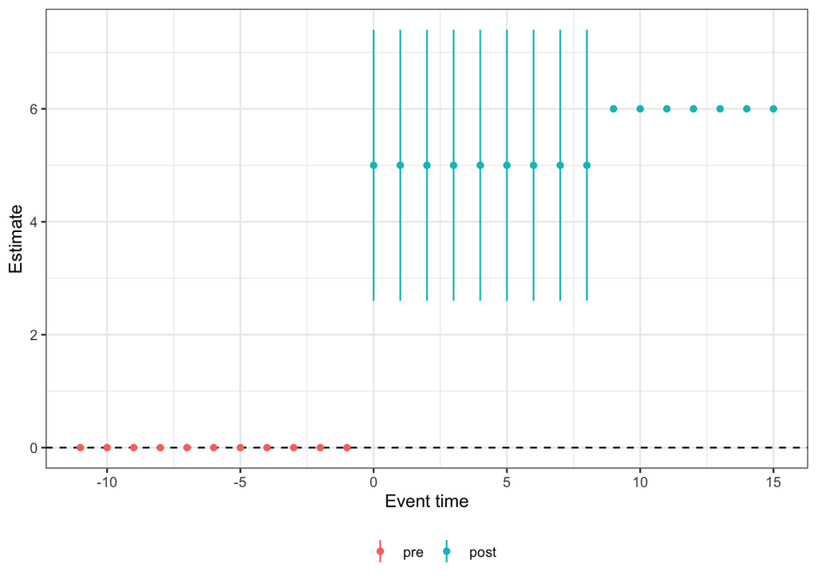

```r
ggplot(s7_bm_ave, aes(x = event_time, y = estimate)) +
  geom_hline(yintercept = 0, lty = 2) +
  geom_point(aes(col = event_time >= 0)) +
  geom_linerange(aes(ymin = lb, ymax = ub, col = event_time >= 0)) +
  labs(y = "Estimate", x = "Event time") +
  theme_bw() +
  scale_color_discrete(labels=c('pre', 'post')) +
  theme(legend.title=element_blank(), legend.position = "bottom")
```

To summarize the effects into one aggregated effect estimate we use the fit_event_jack_sum() function:

```r
s7_bm2 <- fit_event_jack_sum(outcome_var = "outcome",
                            date_var = "time_as_date",
                            unit_var = "state",
                            policy_var = "time_first_trt_date",
                            data = s7,
                            max_time_to = 10e7)
```

```
## Dropping 1
## Dropping 2
## Dropping 3
## Dropping 4
```

```r
s7_bm2$estimate
```

```
## [1] 5.4375
```

```r
s7_bm3 <- fit_event_jack_sum_hte(outcome_var = "outcome",
                            date_var = "time_as_date",
                            unit_var = "state",
                            policy_var = "time_first_trt_date",
                            data = s7,
                            max_time_to = 10e7)
```

```
## Dropping 1
## Dropping 2
## Dropping 3
## Dropping 4
```

```r
s7_bm3$estimate
```

```
## [1] 5
```

The aggregated effect estimate equals 5.4375, equivalent to the 📙 **Causal Effect B**.

## Summary

When the treatment effect is staggered and heterogeneous, the TWFE estimate aggregates the heterogeneous effects using weights that are calculated by the model and not concordant with weights researchers would intuitively choose. In this example, this led to an effect estimate that was lower than the three causal effect estimates we aimed to estimate. Thus, TWFE performs unfavorably when effects are heterogeneous across adoption cohorts.

**Recommendation:** Use the `aggte()` function with `type = "group"` to estimate effects separately for each adoption cohort alongside confidence intervals. Examine the difference in effects across adoption cohorts and their associated precision, remembering that the number of units contributing to each adoption cohort will affect the width of its confidence interval, which may make it difficult to make conclusive statements about heterogeneity across adoption cohorts in the presence of limited data.